# cobb_douglas_spain_v2_clean

[video not shown]

## Resumen

Este trabajo estima una función de producción Cobb-Douglas para la economía española en el período 1995–2021 utilizando datos de Eurostat, EU KLEMS y la Fundación BBVA-Ivie. Los resultados muestran rendimientos constantes a escala (α + β = 1,008), con una elasticidad del capital α = 0,407 y una elasticidad del trabajo β = 0,601, consistentes con la teoría neoclásica (Mankiw, 2019, cap. 3). Se detecta y corrige la autocorrelación serial siguiendo a Wooldridge (2019, cap. 12) mediante primeras diferencias, variables ficticias para rupturas estructurales y errores estándar HAC. La Productividad Total de los Factores (PTF) muestra una tendencia decreciente durante la burbuja inmobiliaria (2000–2009) y una recuperación posterior, lo que sugiere que el crecimiento español fue predominantemente extensivo durante el período expansivo.

**Palabras clave:** Cobb-Douglas, PTF, Autocorrelación, Economía española, Errores HAC

**Códigos JEL:** C22, E23, O47

::: {.callout-note}

## Hallazgos principales

:::

## Datos y preparación

### Librerías y configuración

```python
import pandas as pd
import numpy as np
import matplotlib.pyplot as plt
import statsmodels.api as sm
from statsmodels.stats.stattools import durbin_watson
from statsmodels.stats.diagnostic import acorr_breusch_godfrey
from statsmodels.tsa.filters.hp_filter import hpfilter
from scipy import stats
import plotly.graph_objects as go
import plotly.figure_factory as ff
from plotly.subplots import make_subplots
from great_tables import GT, md, style, loc
from stargazer.stargazer import Stargazer
import eurostat
import warnings
import plotly.io as pio
pio.renderers.default = 'notebook'
warnings.filterwarnings('ignore')

# Estilo institucional para gráficas matplotlib
plt.rcParams.update({
    'font.family': 'serif',
    'font.size': 11,
    'axes.spines.top': False,
    'axes.spines.right': False,
    'axes.grid': True,
    'grid.alpha': 0.3,
    'grid.linestyle': '--',
    'figure.facecolor': 'white',
    'axes.facecolor': 'white',
    'axes.titlesize': 12,
    'axes.titleweight': 'bold',
})
import plotly.io as pio

# Tema personalizado edalytics
pio.templates["edalytics"] = go.layout.Template(
    layout=go.Layout(
        font=dict(family='Georgia, serif', size=12, color='#2c3e50'),
        paper_bgcolor='#fafaf8',
        plot_bgcolor='#fafaf8',
        title=dict(
            font=dict(family='Georgia, serif', size=14, color='#2c3e50'),
            x=0
        ),
        xaxis=dict(
            gridcolor='#e8e8e4',
            gridwidth=0.5,
            linecolor='#2c3e50',
            tickfont=dict(color='#2c3e50'),
            title=dict(font=dict(color='#2c3e50'))
        ),
        yaxis=dict(
            gridcolor='#e8e8e4',
            gridwidth=0.5,
            linecolor='#2c3e50',
            tickfont=dict(color='#2c3e50'),
            title=dict(font=dict(color='#2c3e50'))
        ),
        legend=dict(
            bgcolor='#fafaf8',
            bordercolor='#e8e8e4',
            borderwidth=1,
            font=dict(color='#2c3e50')
        ),
        colorway=['#2c3e50', '#e74c3c', '#27ae60', '#3498db', '#e67e22', '#9b59b6']
    )
)

pio.templates.default = "edalytics"
print("Librerías cargadas ✓")
```

```
Librerías cargadas ✓
```

### Fuentes de datos

Los datos utilizados en este trabajo provienen de tres fuentes institucionales:

| Variable | Fuente | Código | Descripción |
| --- | --- | --- | --- |
| Y — PIB real | Eurostat | `nama_10_gdp` | Volumen encadenado 2005, M€ |
| L — Horas trabajadas | EU KLEMS 2024 | Hoja `H_EMP` | Total horas trabajadas, miles |
| K — Stock de capital | Fundación BBVA-Ivie | Activos básicos | Stock neto riqueza, precios constantes 2020 |

La principal mejora respecto a versiones anteriores es el uso del **stock neto de capital real** de la Fundación BBVA-Ivie en lugar de la Formación Bruta de Capital Fijo (FBCF) como proxy. Esta diferencia es crucial: la FBCF es un flujo de inversión anual, mientras que el stock neto es el capital acumulado correctamente medido, lo que permite una estimación fiable de la elasticidad del capital α.

```python
# ── PIB REAL ──────────────────────────────────────────────
pib_raw = eurostat.get_data_df('nama_10_gdp')

pib_es = pib_raw[
    (pib_raw['geo\\TIME_PERIOD'] == 'ES') &
    (pib_raw['na_item'] == 'B1GQ') &
    (pib_raw['unit'] == 'CLV05_MEUR')
].copy()

year_cols = [c for c in pib_es.columns if c.isdigit()]
pib_long = pib_es.melt(
    id_vars=['geo\\TIME_PERIOD'], value_vars=year_cols,
    var_name='year', value_name='GDP'
)
pib_long['year'] = pib_long['year'].astype(int)
pib_long = pib_long[['year', 'GDP']].dropna().reset_index(drop=True)

# ── PIB NOMINAL (para deflactor) ──────────────────────────
pib_nom_raw = pib_raw[
    (pib_raw['geo\\TIME_PERIOD'] == 'ES') &
    (pib_raw['na_item'] == 'B1GQ') &
    (pib_raw['unit'] == 'CP_MEUR')
].copy()
pib_nom_long = pib_nom_raw.melt(
    id_vars=['geo\\TIME_PERIOD'], value_vars=year_cols,
    var_name='year', value_name='GDP_nom'
)
pib_nom_long['year'] = pib_nom_long['year'].astype(int)
pib_nom_long = pib_nom_long[['year', 'GDP_nom']].dropna().reset_index(drop=True)

print(f"PIB: {len(pib_long)} observaciones ({pib_long['year'].min()}-{pib_long['year'].max()})")
```

```
PIB: 31 observaciones (1995-2025)
```

```python
# ── HORAS TRABAJADAS — EU KLEMS ───────────────────────────
emp_raw = pd.read_excel('data/ES_national accounts.xlsx', sheet_name='H_EMP')
emp_tot = emp_raw[emp_raw['nace_r2_code'] == 'TOT'].copy()

year_cols_emp = [c for c in emp_tot.columns if str(c).isdigit()]
emp_long = emp_tot.melt(
    id_vars=['nace_r2_code'], value_vars=year_cols_emp,
    var_name='year', value_name='L'
)
emp_long['year'] = emp_long['year'].astype(int)
emp_long = emp_long[['year', 'L']].dropna().reset_index(drop=True)
emp_long['L'] = emp_long['L'] / 1000  # miles a millones de horas

# ── COMPENSACIÓN EMPLEADOS — EU KLEMS ─────────────────────
comp_raw = pd.read_excel('data/ES_national accounts.xlsx', sheet_name='COMP')
comp_tot = comp_raw[comp_raw['nace_r2_code'] == 'TOT'].copy()
comp_long = comp_tot.melt(
    id_vars=['nace_r2_code'], value_vars=year_cols_emp,
    var_name='year', value_name='COMP'
)
comp_long['year'] = comp_long['year'].astype(int)
comp_long = comp_long[['year', 'COMP']].dropna().reset_index(drop=True)

print(f"Horas trabajadas: {len(emp_long)} observaciones ({emp_long['year'].min()}-{emp_long['year'].max()})")
```

```
Horas trabajadas: 27 observaciones (1995-2021)
```

```python
# ── STOCK DE CAPITAL — BBVA-IVIE ──────────────────────────
df_ivie = pd.read_csv(
    '/Users/eduardromero/Documents/edalytics_website/posts/mi-proyecto/data/DE_2026_BBDD_Stock_nacional-activosbasicos.csv',
    sep=None, engine='python', encoding='utf-8-sig'
)

k_ivie = df_ivie[
    (df_ivie['VARIABLE'] == 'Stock de capital neto riqueza') &
    (df_ivie['ACTIVO'] == '0. Total') &
    (df_ivie['RAMA'] == '0. Total') &
    (df_ivie['UNIDAD'] == 'Miles de euros constantes base 2020')
].copy()

year_cols_k = [c for c in k_ivie.columns if str(c).isdigit()]
cap_long = k_ivie.melt(
    id_vars=['LUGAR'], value_vars=year_cols_k,
    var_name='year', value_name='K'
)
cap_long['year'] = cap_long['year'].astype(int)
cap_long['K'] = cap_long['K'].astype(str).str.replace(',', '.').astype(float) / 1e6
cap_long = cap_long[['year', 'K']].dropna().reset_index(drop=True)

print(f"Stock de capital: {len(cap_long)} observaciones ({cap_long['year'].min()}-{cap_long['year'].max()})")
```

```
Stock de capital: 62 observaciones (1964-2025)
```

```python
# ── MERGE Y LIMPIEZA FINAL ────────────────────────────────
df = pib_long.merge(emp_long, on='year').merge(cap_long, on='year')
df = df.merge(pib_nom_long, on='year').merge(comp_long, on='year')
df['K'] = df['K'] / 1000  # miles a millones de euros

# Período común: 1995-2021
df = df[df['year'].between(1995, 2021)].reset_index(drop=True)

print(f"DataFrame final: {df.shape[0]} observaciones, {df.shape[1]} columnas")
print(f"Período: {df['year'].min()} - {df['year'].max()}")
print(f"NaN totales: {df.isna().sum().sum()}")
print(df[['year', 'GDP', 'K', 'L']].head())
```

```
DataFrame final: 27 observaciones, 6 columnas
Período: 1995 - 2021
NaN totales: 0
   year       GDP         K          L
0  1995  649404.1  2.300542  24056.454
1  1996  666336.7  2.367656  24467.619
2  1997  690240.2  2.439775  25423.001
3  1998  719934.2  2.525004  26676.910
4  1999  751675.1  2.622690  27985.967
```

### Estadísticos descriptivos

```python
desc = df[['GDP', 'K', 'L']].describe().T
desc.columns = ['Obs.', 'Media', 'Desv. típica', 'Mín.', 'P25', 'Mediana', 'P75', 'Máx.']
desc = desc.drop('Obs.', axis=1).round(2)
desc.index = ['PIB real (M€)', 'Stock de capital (M€)', 'Horas trabajadas (M)']
desc = desc.reset_index().rename(columns={'index': 'Variable'})

(
    GT(desc)
    .tab_header(
        title=md("**Tabla 0: Estadísticos Descriptivos**"),
        subtitle=md("España 1995–2021 | Datos anuales")
    )
    .tab_source_note(md("*Fuentes: Eurostat, EU KLEMS 2024, Fundación BBVA-Ivie*"))
    .fmt_number(columns=desc.columns[1:].tolist(), decimals=2, use_seps=True)
    .tab_style(
        style=style.fill(color='#f8f9fa'),
        locations=loc.body(rows=[0, 2])
    )
    .tab_style(
        style=style.text(weight='bold', color='#2c3e50'),
        locations=loc.column_labels()
    )
    .tab_style(
        style=style.borders(sides='bottom', weight='2px', color='#2c3e50'),
        locations=loc.column_labels()
    )
    .tab_options(
        table_font_size='13px',
        heading_title_font_size='15px',
        table_border_top_color='#2c3e50',
        table_border_bottom_color='#2c3e50',
    )
)
```

**Tabla 0: Estadísticos Descriptivos**

España 1995–2021 | Datos anuales

[output not shown]

*Fuentes: Eurostat, EU KLEMS 2024, Fundación BBVA-Ivie*

### Evolución de las variables

El gráfico siguiente muestra la evolución de las tres variables durante el período de estudio. Se aprecian claramente dos episodios de perturbación: la crisis financiera de 2008–2013, que provocó una caída pronunciada del empleo aunque el stock de capital continuó creciendo, y el COVID-19 en 2020, que generó una contracción simultánea del PIB y las horas trabajadas. La rigidez del stock de capital —que no disminuye en ningún momento del período— es uno de los rasgos más llamativos de la economía española.

```python
fig = make_subplots(
    rows=3, cols=1, shared_xaxes=True,
    subplot_titles=['PIB real (M€)', 'Stock de capital (M€)', 'Horas trabajadas (M)'],
    vertical_spacing=0.08
)

series = [('GDP', '#2c3e50', 1), ('K', '#e74c3c', 2), ('L', '#27ae60', 3)]

for col, color, row in series:
    fig.add_trace(go.Scatter(
        x=df['year'], y=df[col], mode='lines+markers',
        line=dict(color=color, width=2), marker=dict(size=4),
        hovertemplate='<b>%{x}</b><br>%{y:,.1f}<extra></extra>',
        showlegend=False
    ), row=row, col=1)
    fig.add_vrect(x0=2008, x1=2013, fillcolor='gray', opacity=0.1, row=row, col=1)
    fig.add_vrect(x0=2019, x1=2021, fillcolor='orange', opacity=0.1, row=row, col=1)

fig.update_layout(
    title=dict(text='Variables macroeconómicas — España 1995-2021',
               font=dict(size=14, family='serif')),
    template='edalytics', height=600,
    font=dict(family='serif', size=12), hovermode='x unified'
)
fig.show()
```

[interactive chart not shown]

## Estimación de la función de producción

### Especificación econométrica

La función de producción Cobb-Douglas adopta la forma:

$$Y_t = A \cdot K_t^{\alpha} \cdot L_t^{\beta}$$

donde $Y$ es el PIB real, $K$ el stock neto de capital, $L$ las horas trabajadas y $A$ la Productividad Total de los Factores (PTF). Aplicando logaritmos naturales, la expresión se linealiza:

$$\ln(Y_t) = \ln(A) + \alpha \ln(K_t) + \beta \ln(L_t) + \varepsilon_t$$

Esta transformación permite estimar α y β como elasticidades: un incremento del 1% en el capital aumenta el PIB en α%, y análogamente para el trabajo. Los parámetros se denominan *rendimientos a escala* cuando se evalúan conjuntamente: si α + β = 1 los rendimientos son constantes; si α + β > 1 son crecientes.

```python
# Transformación logarítmica
for col in ['GDP', 'K', 'L']:
    df[f'ln_{col}'] = np.log(df[col])

# Variables derivadas
df['y'] = df['GDP'] / df['L']   # PIB por hora trabajada
df['k'] = df['K'] / df['L']     # Capital por hora trabajada
df['PTF'] = df['GDP'] / (df['K']**0.407 * df['L']**0.601)  # provisional

print("Variables logarítmicas creadas ✓")
print(df[['year', 'ln_GDP', 'ln_K', 'ln_L']].head())
```

```
Variables logarítmicas creadas ✓
   year     ln_GDP      ln_K       ln_L
0  1995  13.383810  0.833145  10.088159
1  1996  13.409550  0.861900  10.105106
2  1997  13.444795  0.891906  10.143410
3  1998  13.486915  0.926243  10.191554
4  1999  13.530059  0.964201  10.239458
```

### Modelo en niveles (largo plazo)

La estimación por MCO del modelo en niveles proporciona las elasticidades estructurales del capital y del trabajo. Como se discute en Wooldridge (2019, cap. 12), la presencia de autocorrelación serial no invalida la insesgadez de los estimadores, pero sí compromete la eficiencia y la validez de los errores estándar convencionales. Por ello se aplican errores estándar robustos HAC (Newey-West) para corregir este problema.

```python
Y_n = df['ln_GDP']
X_n = sm.add_constant(df[['ln_K', 'ln_L']])

modelo_niveles     = sm.OLS(Y_n, X_n).fit()
modelo_niveles_hac = sm.OLS(Y_n, X_n).fit(cov_type='HAC', cov_kwds={'maxlags': 2})

alpha = modelo_niveles_hac.params['ln_K']
beta  = modelo_niveles_hac.params['ln_L']
A     = np.exp(modelo_niveles_hac.params['const'])

print(f"α (capital)  = {alpha:.4f}  (p = {modelo_niveles_hac.pvalues['ln_K']:.4f})")
print(f"β (trabajo)  = {beta:.4f}  (p = {modelo_niveles_hac.pvalues['ln_L']:.4f})")
print(f"α + β        = {alpha + beta:.4f}")
print(f"A estimado   = {A:.4f}")
print(f"R²           = {modelo_niveles_hac.rsquared:.4f}")
print(f"DW           = {durbin_watson(modelo_niveles_hac.resid):.4f}")
```

```
α (capital)  = 0.4071  (p = 0.0000)
β (trabajo)  = 0.6010  (p = 0.0000)
α + β        = 1.0081
A estimado   = 1078.2650
R²           = 0.9902
DW           = 0.7131
```

### Diagnóstico de autocorrelación serial

El estadístico de Durbin-Watson (DW) y el contraste de Breusch-Godfrey (BG) permiten detectar la presencia de autocorrelación serial en los residuos. Un valor de DW próximo a 2 indica ausencia de autocorrelación; valores próximos a 0 señalan autocorrelación positiva. El contraste BG es más general que el DW, pues detecta autocorrelación de cualquier orden AR(p) (Wooldridge, 2019, cap. 12).

```python
dw_niveles = durbin_watson(modelo_niveles.resid)
bg_niveles = acorr_breusch_godfrey(modelo_niveles, nlags=2)

print("=== Diagnóstico de autocorrelación — Modelo en niveles ===")
print(f"Durbin-Watson  : {dw_niveles:.4f}  {'⚠️ Autocorrelación positiva' if dw_niveles < 1.5 else '✅ OK'}")
print(f"BG estadístico : {bg_niveles[0]:.4f}")
print(f"BG p-valor     : {bg_niveles[1]:.4f}  {'⚠️ Rechazamos H0: hay autocorrelación' if bg_niveles[1] < 0.05 else '✅ No hay autocorrelación'}")
```

```
=== Diagnóstico de autocorrelación — Modelo en niveles ===
Durbin-Watson  : 0.7131  ⚠️ Autocorrelación positiva
BG estadístico : 11.1949
BG p-valor     : 0.0037  ⚠️ Rechazamos H0: hay autocorrelación
```

### Corrección: modelo en primeras diferencias (corto plazo)

La transformación en primeras diferencias elimina la tendencia común de las series y reduce la autocorrelación. El modelo estimado es:

$$\Delta\ln(Y_t) = c + \alpha \Delta\ln(K_t) + \beta \Delta\ln(L_t) + \delta_1 d_{2009} + \delta_2 d_{2020} + \varepsilon_t$$

donde $c$ captura el crecimiento autónomo de la PTF, y las variables ficticias $d_{2009}$ y $d_{2020}$ controlan los shocks estructurales de la crisis financiera y el COVID-19 respectivamente. Los errores estándar HAC garantizan inferencia válida en presencia de heterocedasticidad y autocorrelación residual.

```python
# Primeras diferencias
for col in ['ln_GDP', 'ln_K', 'ln_L']:
    df[f'd{col}'] = df[col].diff()

df_diff = df.dropna(subset=['dln_GDP', 'dln_K', 'dln_L']).copy()
df_diff['d2009'] = (df_diff['year'] == 2009).astype(int)
df_diff['d2020'] = (df_diff['year'] == 2020).astype(int)

Y_d = df_diff['dln_GDP']
X_d = sm.add_constant(df_diff[['dln_K', 'dln_L', 'd2009', 'd2020']])

modelo_dummy  = sm.OLS(Y_d, X_d).fit()
modelo_final  = sm.OLS(Y_d, X_d).fit(cov_type='HAC', cov_kwds={'maxlags': 2})

bg_final = acorr_breusch_godfrey(modelo_dummy, nlags=2)
dw_final = durbin_watson(modelo_dummy.resid)

print("=== Diagnóstico — Modelo en diferencias + dummies + HAC ===")
print(f"DW     : {dw_final:.4f}  {'✅ OK' if 1.5 < dw_final < 2.5 else '⚠️'}")
print(f"BG p   : {bg_final[1]:.4f}  {'✅ No autocorrelación' if bg_final[1] > 0.05 else '⚠️ Autocorrelación'}")
print(f"R²     : {modelo_final.rsquared:.4f}")
```

```
=== Diagnóstico — Modelo en diferencias + dummies + HAC ===
DW     : 2.1032  ✅ OK
BG p   : 0.0909  ✅ No autocorrelación
R²     : 0.9885
```

### Resultados de la estimación

La Tabla 1 presenta los resultados de los dos modelos estimados. El Modelo 1 (niveles + HAC) proporciona las elasticidades estructurales a largo plazo: α = 0,407 y β = 0,601, con rendimientos prácticamente constantes a escala (α + β = 1,008). El Modelo 2 (primeras diferencias + dummies + HAC) está diseñado para la inferencia estadística a corto plazo: el estadístico DW = 2,103 y el p-valor BG = 0,091 confirman la ausencia de autocorrelación serial en los residuos.

```python
from stargazer.stargazer import Stargazer

tabla = Stargazer([modelo_niveles_hac, modelo_final])
tabla.title('Tabla 1: Resultados de la Estimación — Cobb-Douglas España 1995-2021')
tabla.custom_columns(['Niveles + HAC', 'Diferencias + HAC'], [1, 1])
tabla.show_model_numbers(False)
tabla.add_line('Durbin-Watson',
               [f"{durbin_watson(modelo_niveles_hac.resid):.3f}",
                f"{durbin_watson(modelo_final.resid):.3f}"])
tabla.add_line('α + β',
               [f"{modelo_niveles_hac.params['ln_K'] + modelo_niveles_hac.params['ln_L']:.3f}", '—'])
tabla
```

Tabla 1: Resultados de la Estimación — Cobb-Douglas España 1995-2021

|  | Niveles + HAC | Diferencias + HAC |
| --- | --- | --- |
| const | 6.983*** | 0.010*** |
|  | (0.329) | (0.001) |
| d2009 |  | -0.001 |
|  |  | (0.002) |
| d2020 |  | -0.037*** |
|  |  | (0.004) |
| dln_K |  | 0.003 |
|  |  | (0.052) |
| dln_L |  | 0.762*** |
|  |  | (0.030) |
| ln_K | 0.407*** |  |
|  | (0.022) |  |
| ln_L | 0.601*** |  |
|  | (0.034) |  |
| Durbin-Watson | 0.713 | 2.103 |
| α + β | 1.008 | — |
| Observations | 27 | 26 |
| R<sup>2</sup> | 0.990 | 0.989 |
| Adjusted R<sup>2</sup> | 0.989 | 0.986 |
| Residual Std. Error | 0.015 (df=24) | 0.004 (df=21) |
| F Statistic | 1065.494*** (df=2; 24) | 8277.794*** (df=4; 21) |
| Note: | *p<0.1; **p<0.05; ***p<0.01 |  |

## Gráficas de Mankiw cap. 3

```python
# Parámetros estimados
alpha = 0.4071
beta  = 0.6010
A     = np.exp(1.3582)
A_cal = df['GDP'].mean() / (df['K'].mean()**alpha * df['L'].mean()**beta)

# Actualizar PTF con parámetros definitivos
df['PTF'] = df['GDP'] / (df['K']**alpha * df['L']**beta)

print(f"α = {alpha} | β = {beta} | A = {A:.4f} | α+β = {alpha+beta:.4f}")
```

```
α = 0.4071 | β = 0.601 | A = 3.8892 | α+β = 1.0081
```

### Función de producción F(K, L̄)

La figura 1 muestra la función de producción agregada evaluada en el nivel medio de empleo del período. La concavidad refleja el producto marginal decreciente del capital: cada unidad adicional de K aporta menos producción que la anterior. Los puntos representan las observaciones reales de PIB y stock de capital para cada año.

```python
L_mean  = df['L'].mean()
K_range = np.linspace(df['K'].min() * 0.9, df['K'].max() * 1.1, 200)
Y_curve = A_cal * K_range**alpha * L_mean**beta

fig = go.Figure()
fig.add_trace(go.Scatter(
    x=K_range, y=Y_curve, mode='lines',
    line=dict(color='#2c3e50', width=2.5),
    name=r'F(K, L̄) teórica'
))
fig.add_trace(go.Scatter(
    x=df['K'], y=df['GDP'], mode='markers+text',
    marker=dict(color='#e74c3c', size=8),
    text=df['year'], textposition='top center',
    textfont=dict(size=8, color='gray'),
    name='Observaciones reales',
    hovertemplate='<b>%{text}</b><br>K: %{x:,.0f} M€<br>PIB: %{y:,.0f} M€<extra></extra>'
))
fig.update_layout(
    title=dict(
        text='Figura 1: Función de Producción F(K, L̄) — España 1995-2021<br>'
             '<sup>Y = A · K<sup>0.407</sup> · L̄<sup>0.601</sup> | α+β = 1,008</sup>',
        font=dict(size=14, family='serif')
    ),
    xaxis_title='Stock neto de capital K (M€)',
    yaxis_title='PIB real (M€)',
    template='edalytics', height=480,
    font=dict(family='serif', size=12),
    legend=dict(orientation='h', yanchor='bottom', y=1.02)
)
fig.show()
```

[interactive chart not shown]

### Producto Marginal del Capital (PMgK)

El producto marginal del capital se obtiene derivando la función de producción respecto a K:

$$PMgK = \frac{\partial Y}{\partial K} = \alpha \cdot A \cdot K^{\alpha-1} \cdot \bar{L}^{\beta} = \alpha \cdot \frac{Y}{K}$$

En equilibrio competitivo, el PMgK es igual al coste real del capital (tipo de interés real). La curva decreciente implica que a mayor stock de capital acumulado, menor es su retorno marginal.

```python
PMgK_curve = alpha * A_cal * K_range**alpha * L_mean**beta / K_range
PMgK_real  = alpha * df['GDP'] / df['K']

fig = go.Figure()
fig.add_trace(go.Scatter(
    x=K_range, y=PMgK_curve, mode='lines',
    line=dict(color='#2c3e50', width=2.5),
    name='PMgK teórico'
))
fig.add_trace(go.Scatter(
    x=df['K'], y=PMgK_real, mode='markers+text',
    marker=dict(color='#e74c3c', size=8),
    text=df['year'], textposition='top center',
    textfont=dict(size=8, color='gray'),
    name='PMgK real',
    hovertemplate='<b>%{text}</b><br>PMgK: %{y:.4f}<extra></extra>'
))
fig.update_layout(
    title=dict(
        text='Figura 2: Producto Marginal del Capital — España 1995-2021<br>'
             '<sup>PMgK = α · Y/K | α = 0,407</sup>',
        font=dict(size=14, family='serif')
    ),
    xaxis_title='Stock neto de capital K (M€)',
    yaxis_title='PMgK',
    template='edalytics', height=450,
    font=dict(family='serif', size=12),
    legend=dict(orientation='h', yanchor='bottom', y=1.02)
)
fig.show()
```

[interactive chart not shown]

### Distribución del ingreso entre factores

En un mercado competitivo, la renta del capital es α·Y y la renta del trabajo es β·Y, donde α y β son las participaciones de cada factor en el PIB. Con rendimientos constantes (α + β ≈ 1), la suma de ambas rentas agota el producto nacional, lo que es consistente con la contabilidad nacional (Mankiw, 2019, cap. 3).

```python
df['renta_K'] = alpha * df['GDP']
df['renta_L'] = beta  * df['GDP']

fig = go.Figure()
fig.add_trace(go.Scatter(
    x=df['year'], y=df['renta_K'],
    mode='lines', stackgroup='one',
    line=dict(color='#2c3e50', width=0),
    fillcolor='rgba(44,62,80,0.7)',
    name=f'Renta del Capital (α = {alpha})'
))
fig.add_trace(go.Scatter(
    x=df['year'], y=df['renta_L'],
    mode='lines', stackgroup='one',
    line=dict(color='#e74c3c', width=0),
    fillcolor='rgba(231,76,60,0.7)',
    name=f'Renta del Trabajo (β = {beta})'
))
fig.add_vrect(x0=2008, x1=2013, fillcolor='gray', opacity=0.1,
              annotation_text='Crisis', annotation_position='top left')
fig.add_vrect(x0=2019, x1=2021, fillcolor='orange', opacity=0.1,
              annotation_text='COVID', annotation_position='top left')
fig.update_layout(
    title=dict(
        text='Figura 3: Distribución del Ingreso entre Factores — España 1995-2021<br>'
             '<sup>α = 0,407 | β = 0,601 | α+β = 1,008</sup>',
        font=dict(size=14, family='serif')
    ),
    xaxis_title='Año', yaxis_title='PIB real (M€)',
    template='edalytics', height=450,
    font=dict(family='serif', size=12),
    legend=dict(orientation='h', yanchor='bottom', y=1.02)
)
fig.show()
```

[interactive chart not shown]

### Función de producción por trabajador f(k) ⭐

Esta es la representación central del modelo de Solow (cap. 7 de Mankiw). Dividiendo la función de producción entre L y usando rendimientos constantes a escala:

$$y = A \cdot k^{\alpha}$$

donde $y = Y/L$ es el PIB por hora trabajada y $k = K/L$ es el capital por hora trabajada. El camino temporal de la economía española revela tres patrones distintos según el período: acumulación durante la burbuja, infrautilización del capital durante la crisis, y recuperación parcial posterior.

```python
# f(k) dinámica con camino temporal
A_pw = df['y'].mean() / (df['k'].mean()**alpha)
k_range = np.linspace(df['k'].min()*0.9, df['k'].max()*1.1, 200)
y_curve = A_pw * k_range**alpha

colores = []
for year in df['year']:
    if year <= 2000:   colores.append('#3498db')
    elif year <= 2007: colores.append('#e74c3c')
    elif year <= 2013: colores.append('#e67e22')
    elif year <= 2019: colores.append('#27ae60')
    else:              colores.append('#9b59b6')

fig = go.Figure()
fig.add_trace(go.Scatter(
    x=k_range, y=y_curve, mode='lines',
    line=dict(color='#2c3e50', width=2, dash='dash'),
    name='f(k) teórica',
    hoverinfo='skip'
))
fig.add_trace(go.Scatter(
    x=df['k'], y=df['y'],
    mode='markers+lines+text',
    marker=dict(color=colores, size=10, line=dict(color='white', width=1)),
    line=dict(color='lightgray', width=1),
    text=df['year'], textposition='top center',
    textfont=dict(size=8),
    hovertemplate='<b>%{text}</b><br>k: %{x:,.1f}<br>y: %{y:,.1f}<extra></extra>',
    showlegend=False
))
for color, label in [
    ('#3498db','Pre-euro (1995-2000)'), ('#e74c3c','Burbuja (2001-2007)'),
    ('#e67e22','Crisis (2008-2013)'), ('#27ae60','Recuperación (2014-2019)'),
    ('#9b59b6','COVID (2020-2021)')
]:
    fig.add_trace(go.Scatter(x=[None], y=[None], mode='markers',
        marker=dict(color=color, size=10), name=label))
fig.update_layout(
    title=dict(
        text='Figura 4: Función de Producción por Trabajador f(k) — España 1995-2021<br>'
             '<sup>y = A·k<sup>α</sup> | Calibrado siguiendo Solow (1957) y MRW (1992)</sup>',
        font=dict(size=14, family='serif')
    ),
    xaxis_title='Capital por hora trabajada k = K/L',
    yaxis_title='PIB por hora trabajada y = Y/L',
    template='edalytics', height=550,
    font=dict(family='serif', size=12),
    legend=dict(orientation='h', yanchor='bottom', y=-0.25)
)
fig.show()
```

[interactive chart not shown]

## Análisis de la Productividad Total de los Factores

### El residuo de Solow

La PTF se calcula como el residuo de Solow: la parte del PIB que no puede explicarse por la acumulación de factores productivos.

$$PTF_t = \frac{Y_t}{K_t^{\alpha} \cdot L_t^{\beta}}$$

Un aumento de la PTF refleja mejoras tecnológicas, organizativas o institucionales que permiten producir más con los mismos recursos. Es el motor del crecimiento económico sostenible a largo plazo (Solow, 1957).

```python
# PTF índice base 2000=100
ptf_base = df[df['year']==2000]['PTF'].values[0]
df['PTF_idx'] = (df['PTF'] / ptf_base) * 100

# Filtro Hodrick-Prescott
ptf_cycle, ptf_trend = hpfilter(df['PTF'], lamb=100)
df['PTF_trend'] = ptf_trend
df['PTF_cycle'] = ptf_cycle
df['PTF_gap']   = (ptf_cycle / ptf_trend) * 100

fig = make_subplots(rows=2, cols=1,
    subplot_titles=['PTF: Nivel real vs Tendencia HP (λ=100)',
                    'Componente cíclico: desviación de la tendencia (%)'],
    vertical_spacing=0.12)

fig.add_trace(go.Scatter(x=df['year'], y=df['PTF'], mode='lines+markers',
    name='PTF real', line=dict(color='#2c3e50', width=2),
    marker=dict(size=5)), row=1, col=1)
fig.add_trace(go.Scatter(x=df['year'], y=df['PTF_trend'], mode='lines',
    name='Tendencia LP', line=dict(color='#e74c3c', width=2.5, dash='dash')),
    row=1, col=1)
fig.add_trace(go.Bar(x=df['year'], y=df['PTF_gap'],
    marker_color=['#e74c3c' if x<0 else '#27ae60' for x in df['PTF_gap']],
    name='Gap PTF', showlegend=False,
    hovertemplate='<b>%{x}</b><br>Gap: %{y:.2f}%<extra></extra>'), row=2, col=1)
fig.add_hline(y=0, line_color='black', line_width=0.5, row=2, col=1)
for row in [1,2]:
    fig.add_vrect(x0=2008, x1=2013, fillcolor='gray', opacity=0.1, row=row, col=1)
    fig.add_vrect(x0=2019, x1=2021, fillcolor='orange', opacity=0.1, row=row, col=1)
fig.update_layout(
    title=dict(text='Figura 5: Descomposición tendencia-ciclo de la PTF — España 1995-2021',
               font=dict(size=14, family='serif')),
    template='edalytics', height=580, font=dict(family='serif', size=12),
    hovermode='x unified', legend=dict(orientation='h', yanchor='bottom', y=1.02)
)
fig.show()
```

[interactive chart not shown]

### Contabilidad del crecimiento (Growth Accounting)

La descomposición del crecimiento del PIB en las contribuciones de cada factor es uno de los instrumentos más utilizados en macroeconomía aplicada. A partir del modelo en primeras diferencias, el crecimiento del PIB se descompone como:

$$\Delta\ln(Y_t) = \underbrace{\alpha \cdot \Delta\ln(K_t)}_{\text{Capital}} + \underbrace{\beta \cdot \Delta\ln(L_t)}_{\text{Trabajo}} + \underbrace{\Delta\ln(A_t)}_{\text{PTF}}$$

donde la contribución de la PTF se obtiene como residuo. Esta descomposición es el estándar metodológico utilizado por la OCDE, el BCE y el Banco de España.

```python
df_diff['contrib_K']   = alpha * df_diff['dln_K']
df_diff['contrib_L']   = beta  * df_diff['dln_L']
df_diff['contrib_PTF'] = df_diff['dln_GDP'] - df_diff['contrib_K'] - df_diff['contrib_L']

fig = go.Figure()
fig.add_trace(go.Bar(x=df_diff['year'], y=df_diff['contrib_K']*100,
    name='Capital (K)', marker_color='#2c3e50',
    hovertemplate='<b>%{x}</b><br>Capital: %{y:.2f}pp<extra></extra>'))
fig.add_trace(go.Bar(x=df_diff['year'], y=df_diff['contrib_L']*100,
    name='Trabajo (L)', marker_color='#e74c3c',
    hovertemplate='<b>%{x}</b><br>Trabajo: %{y:.2f}pp<extra></extra>'))
fig.add_trace(go.Bar(x=df_diff['year'], y=df_diff['contrib_PTF']*100,
    name='PTF', marker_color='#27ae60',
    hovertemplate='<b>%{x}</b><br>PTF: %{y:.2f}pp<extra></extra>'))
fig.add_trace(go.Scatter(x=df_diff['year'], y=df_diff['dln_GDP']*100,
    mode='lines+markers', name='Crecimiento PIB',
    line=dict(color='black', width=2), marker=dict(size=6),
    hovertemplate='<b>%{x}</b><br>PIB: %{y:.2f}%<extra></extra>'))
fig.add_hline(y=0, line_color='black', line_width=0.5)
fig.add_vrect(x0=2008, x1=2013, fillcolor='gray', opacity=0.1,
              annotation_text='Crisis', annotation_position='top left')
fig.add_vrect(x0=2019, x1=2021, fillcolor='orange', opacity=0.1,
              annotation_text='COVID', annotation_position='top left')
fig.update_layout(
    barmode='relative',
    title=dict(
        text='Figura 6: Contabilidad del Crecimiento — España 1996-2021<br>'
             '<sup>Contribuciones al crecimiento del PIB (puntos porcentuales)</sup>',
        font=dict(size=14, family='serif')
    ),
    xaxis_title='Año', yaxis_title='Contribución (pp)',
    template='edalytics', height=500,
    font=dict(family='serif', size=12), hovermode='x unified',
    legend=dict(orientation='h', yanchor='bottom', y=1.02)
)
fig.show()
```

[interactive chart not shown]

### Crecimiento intensivo vs extensivo

El gráfico siguiente contextualiza cada año en el espacio (contribución PTF, crecimiento PIB), permitiendo clasificar el modelo de crecimiento vigente en cada período. Los años situados a la derecha del eje vertical crecen de forma intensiva (liderados por la PTF); los situados a la izquierda lo hacen de forma extensiva (liderados por la acumulación de factores).

```python
colores_s = []
epocas_s  = []
for year in df_diff['year']:
    if year <= 2000:   colores_s.append('#3498db'); epocas_s.append('Pre-euro')
    elif year <= 2007: colores_s.append('#e74c3c'); epocas_s.append('Burbuja')
    elif year <= 2013: colores_s.append('#e67e22'); epocas_s.append('Crisis')
    elif year <= 2019: colores_s.append('#27ae60'); epocas_s.append('Recuperación')
    else:              colores_s.append('#9b59b6'); epocas_s.append('COVID')

fig = go.Figure()
fig.add_trace(go.Scatter(
    x=df_diff['contrib_PTF']*100, y=df_diff['dln_GDP']*100,
    mode='markers+text',
    marker=dict(color=colores_s, size=10, line=dict(color='white', width=1)),
    text=df_diff['year'], textposition='top center', textfont=dict(size=9),
    hovertemplate='<b>%{text}</b><br>PTF: %{x:.2f}pp<br>PIB: %{y:.2f}%<extra></extra>',
    name=''
))
fig.add_vline(x=0, line_dash='dash', line_color='gray', line_width=1)
fig.add_hline(y=0, line_dash='dash', line_color='gray', line_width=1)
fig.add_annotation(x=2, y=6, text="Crecimiento intensivo<br>(liderado por PTF)",
    showarrow=False, font=dict(color='#27ae60', size=10))
fig.add_annotation(x=-3, y=6, text="Crecimiento extensivo<br>(liderado por factores)",
    showarrow=False, font=dict(color='#e74c3c', size=10))
fig.add_annotation(x=2, y=-8, text="Recesión productiva<br>(PTF resiliente)",
    showarrow=False, font=dict(color='#3498db', size=10))
fig.add_annotation(x=-3, y=-8, text="Recesión profunda<br>(todos los factores caen)",
    showarrow=False, font=dict(color='#e67e22', size=10))
for color, label in [
    ('#3498db','Pre-euro (1995-2000)'), ('#e74c3c','Burbuja (2001-2007)'),
    ('#e67e22','Crisis (2008-2013)'), ('#27ae60','Recuperación (2014-2019)'),
    ('#9b59b6','COVID (2020-2021)')
]:
    fig.add_trace(go.Scatter(x=[None], y=[None], mode='markers',
        marker=dict(color=color, size=10), name=label))
fig.update_layout(
    title=dict(
        text='Figura 7: Crecimiento Intensivo vs Extensivo — España 1996-2021<br>'
             '<sup>Contribución PTF (eje x) vs Crecimiento PIB (eje y)</sup>',
        font=dict(size=14, family='serif')
    ),
    xaxis_title='Contribución de la PTF (pp)',
    yaxis_title='Crecimiento del PIB (%)',
    template='edalytics', height=550,
    font=dict(family='serif', size=12),
    legend=dict(orientation='h', yanchor='bottom', y=-0.2)
)
fig.show()
```

[interactive chart not shown]

## Estructura del capital español

### Composición por tipo de activo

```python
activos_nombres = {
    '1.1. Viviendas': 'Vivienda',
    '1.2. Otras construcciones': 'Otras construcciones',
    '1.3. Equipo de transporte': 'Equipo de transporte',
    '1.4. Maquinaria, equipo y otros activos': 'Maquinaria y equipo',
    '2. Activos inmateriales': 'Activos intangibles'
}

colores_activos = {
    'Vivienda': '#e74c3c',
    'Otras construcciones': '#e67e22',
    'Equipo de transporte': '#3498db',
    'Maquinaria y equipo': '#27ae60',
    'Activos intangibles': '#9b59b6'
}

dfs_activos = []
for activo_orig, activo_nuevo in activos_nombres.items():
    temp = df_ivie[
        (df_ivie['VARIABLE'] == 'Stock de capital neto riqueza') &
        (df_ivie['ACTIVO'] == activo_orig) &
        (df_ivie['RAMA'] == '0. Total') &
        (df_ivie['UNIDAD'] == 'Miles de euros constantes base 2020')
    ].copy()
    if len(temp) > 0:
        year_cols_a = [c for c in temp.columns if str(c).isdigit()]
        temp_long = temp.melt(id_vars=['ACTIVO'], value_vars=year_cols_a,
                              var_name='year', value_name='K_activo')
        temp_long['year'] = temp_long['year'].astype(int)
        temp_long['K_activo'] = (temp_long['K_activo'].astype(str)
                                 .str.replace(',','.').astype(float) / 1e6)
        temp_long['ACTIVO'] = activo_nuevo
        dfs_activos.append(temp_long[['year','ACTIVO','K_activo']].dropna())

df_activos = pd.concat(dfs_activos)
df_activos = df_activos[df_activos['year'].between(1995, 2021)]
df_activos_pivot = df_activos.pivot(index='year', columns='ACTIVO', values='K_activo')

print("Activos desagregados cargados ✓")
print(df_activos_pivot.tail(3))
```

```
Activos desagregados cargados ✓
ACTIVO  Activos intangibles  ...     Vivienda
year                         ...
2019             148.424803  ...  2249.315733
2020             150.022055  ...  2288.441349
2021             154.319794  ...  2327.651274

[3 rows x 5 columns]
```

```python
fig = go.Figure()
for activo, color in colores_activos.items():
    if activo in df_activos_pivot.columns:
        fig.add_trace(go.Bar(
            x=df_activos_pivot.index, y=df_activos_pivot[activo],
            name=activo, marker_color=color,
            hovertemplate=f'<b>%{{x}}</b><br>{activo}: %{{y:,.1f}} M€<extra></extra>'
        ))
fig.add_vrect(x0=2008, x1=2013, fillcolor='gray', opacity=0.1,
              annotation_text='Crisis', annotation_position='top left')
fig.add_vrect(x0=2019, x1=2021, fillcolor='orange', opacity=0.1,
              annotation_text='COVID', annotation_position='top left')
fig.update_layout(
    barmode='stack',
    title=dict(
        text='Figura 8: Stock de Capital por Tipo de Activo — España 1995-2021<br>'
             '<sup>Millones de euros constantes (base 2020) | Fuente: BBVA-Ivie</sup>',
        font=dict(size=14, family='serif')
    ),
    xaxis_title='Año', yaxis_title='Stock de capital (M€)',
    template='edalytics', height=500,
    font=dict(family='serif', size=12), hovermode='x unified',
    legend=dict(orientation='h', yanchor='bottom', y=1.02)
)
fig.show()
```

[interactive chart not shown]

### Eficiencia del capital

La eficiencia del capital se define como la ratio PIB/K: cuánto PIB genera cada euro de capital instalado. Una caída sostenida de este indicador revela que la economía acumula capital a mayor velocidad de la que puede utilizarlo productivamente, lo que apunta a una mala asignación de los recursos de inversión.

```python
df['capital_eff'] = df['GDP'] / df['K']
ce_base = df[df['year']==1995]['capital_eff'].values[0]
df['capital_eff_idx'] = (df['capital_eff'] / ce_base) * 100
df['capital_eff_g']   = df['capital_eff'].pct_change() * 100

fig = make_subplots(rows=1, cols=2,
    subplot_titles=['Índice eficiencia del capital (1995=100)',
                    'Tasa de variación anual (%)'],
    horizontal_spacing=0.12)

fig.add_trace(go.Scatter(
    x=df['year'], y=df['capital_eff_idx'], mode='lines+markers',
    line=dict(color='#8e44ad', width=2.5), marker=dict(size=6),
    fill='tozeroy', fillcolor='rgba(142,68,173,0.08)',
    hovertemplate='<b>%{x}</b><br>Índice: %{y:.1f}<extra></extra>',
    name='Eficiencia'
), row=1, col=1)
fig.add_hline(y=100, line_dash='dot', line_color='gray', row=1, col=1)

fig.add_trace(go.Bar(
    x=df['year'], y=df['capital_eff_g'],
    marker_color=['#e74c3c' if x<0 else '#27ae60' for x in df['capital_eff_g'].fillna(0)],
    hovertemplate='<b>%{x}</b><br>Variación: %{y:.2f}%<extra></extra>',
    name='Variación', showlegend=False
), row=1, col=2)
fig.add_hline(y=0, line_color='black', line_width=0.5, row=1, col=2)

for col in [1,2]:
    fig.add_vrect(x0=2008, x1=2013, fillcolor='gray', opacity=0.1, row=1, col=col)
    fig.add_vrect(x0=2019, x1=2021, fillcolor='orange', opacity=0.1, row=1, col=col)

fig.update_layout(
    title=dict(
        text='Figura 9: Eficiencia del Capital — España 1995-2021<br>'
             '<sup>PIB por unidad de stock de capital | Proxy del PMgK</sup>',
        font=dict(size=14, family='serif')
    ),
    template='edalytics', height=430,
    font=dict(family='serif', size=12), showlegend=False, hovermode='x unified'
)
fig.show()
```

[interactive chart not shown]

### Productividad laboral y salarios reales

En un mercado de trabajo competitivo, los salarios reales deberían evolucionar en paralelo a la productividad laboral (PMgL = W/P). Las desviaciones persistentes entre ambas magnitudes señalan la existencia de imperfecciones en el mercado laboral o cambios en la distribución funcional del ingreso.

```python
df['labor_prod'] = df['GDP'] / df['L']
df_w = df.merge(pib_nom_long, on='year', suffixes=('', '_nom2'))
df_w['deflactor']    = df_w['GDP_nom'] / df_w['GDP']
df_w['comp_real']    = df_w['COMP'] / df_w['deflactor']  # COMP ya está en df
df_w['wage_real_ph'] = df_w['comp_real'] / df_w['L']

base = df_w[df_w['year']==1995]
df_w['prod_idx']      = (df_w['labor_prod']  / base['labor_prod'].values[0]) * 100
df_w['wage_real_idx'] = (df_w['wage_real_ph'] / base['wage_real_ph'].values[0]) * 100
df_w['wage_share']    = (df_w['COMP'] / df_w['GDP_nom']) * 100

fig = go.Figure()
fig.add_trace(go.Scatter(x=df_w['year'], y=df_w['prod_idx'],
    mode='lines+markers', name='Productividad laboral',
    line=dict(color='#2c3e50', width=2.5), marker=dict(size=6),
    hovertemplate='<b>%{x}</b><br>Productividad: %{y:.1f}<extra></extra>'))
fig.add_trace(go.Scatter(x=df_w['year'], y=df_w['wage_real_idx'],
    mode='lines+markers', name='Compensación real/hora',
    line=dict(color='#e74c3c', width=2.5, dash='dot'), marker=dict(size=6),
    hovertemplate='<b>%{x}</b><br>Compensación: %{y:.1f}<extra></extra>'))
fig.add_trace(go.Scatter(x=df_w['year'], y=df_w['prod_idx'],
    mode='none', fill=None, showlegend=False))
fig.add_trace(go.Scatter(x=df_w['year'], y=df_w['wage_real_idx'],
    mode='none', fill='tonexty', fillcolor='rgba(231,76,60,0.1)',
    name='Brecha productividad-salarios'))
fig.add_hline(y=100, line_dash='dot', line_color='gray', line_width=1)
fig.add_vrect(x0=2008, x1=2013, fillcolor='gray', opacity=0.1,
              annotation_text='Crisis', annotation_position='top left')
fig.add_vrect(x0=2019, x1=2021, fillcolor='orange', opacity=0.1,
              annotation_text='COVID', annotation_position='top left')
fig.update_layout(
    title=dict(
        text='Figura 10: Productividad Laboral vs Compensación Real — España 1995-2021<br>'
             '<sup>Índice 1995=100 | La brecha refleja la evolución de la wage share</sup>',
        font=dict(size=14, family='serif')
    ),
    xaxis_title='Año', yaxis_title='Índice (1995=100)',
    template='edalytics', height=450,
    font=dict(family='serif', size=12), hovermode='x unified',
    legend=dict(orientation='h', yanchor='bottom', y=1.02)
)
fig.show()
```

[interactive chart not shown]

## Comparativa europea

```python
paises_comp = ['ES', 'DE', 'FR', 'IT', 'PT', 'EU27_2020']
nombres_paises = {'ES':'España','DE':'Alemania','FR':'Francia',
                  'IT':'Italia','PT':'Portugal','EU27_2020':'UE-27'}

pib_multi = pib_raw[
    (pib_raw['geo\\TIME_PERIOD'].isin(paises_comp)) &
    (pib_raw['na_item'] == 'B1GQ') &
    (pib_raw['unit'] == 'CLV05_MEUR')
].copy()

year_cols_m = [c for c in pib_multi.columns if c.isdigit()]
pib_ml = pib_multi.melt(id_vars=['geo\\TIME_PERIOD'], value_vars=year_cols_m,
                         var_name='year', value_name='GDP')
pib_ml['year'] = pib_ml['year'].astype(int)
pib_ml = pib_ml[(pib_ml['year'].between(1995,2021)) & pib_ml['GDP'].notna()].copy()
pib_ml['country'] = pib_ml['geo\\TIME_PERIOD'].map(nombres_paises)

def idx_base(group):
    base = group[group['year']==1995]['GDP'].values
    if len(base)>0: group['GDP_idx'] = (group['GDP']/base[0])*100
    return group

pib_ml = pib_ml.groupby('country').apply(idx_base).reset_index(drop=True)

colores_p = {'España':'#e74c3c','Alemania':'#2c3e50','Francia':'#3498db',
             'Italia':'#e67e22','Portugal':'#27ae60','UE-27':'black'}

fig = go.Figure()
for country, color in colores_p.items():
    data = pib_ml[pib_ml['country']==country]
    fig.add_trace(go.Scatter(
        x=data['year'], y=data['GDP_idx'], mode='lines+markers',
        name=country,
        line=dict(color=color,
                  width=3 if country in ['España','UE-27'] else 1.5,
                  dash='dash' if country=='UE-27' else 'solid'),
        marker=dict(size=4),
        hovertemplate=f'<b>%{{x}}</b><br>{country}: %{{y:.1f}}<extra></extra>'
    ))
fig.add_hline(y=100, line_dash='dot', line_color='gray', line_width=1)
fig.add_vrect(x0=2008, x1=2013, fillcolor='gray', opacity=0.1,
              annotation_text='Crisis', annotation_position='top left')
fig.add_vrect(x0=2019, x1=2021, fillcolor='orange', opacity=0.1,
              annotation_text='COVID', annotation_position='top left')
fig.update_layout(
    title=dict(
        text='Figura 11: Crecimiento del PIB — España vs Europa 1995-2021<br>'
             '<sup>Índice 1995=100 | PIB real en volumen encadenado</sup>',
        font=dict(size=14, family='serif')
    ),
    xaxis_title='Año', yaxis_title='Índice (1995=100)',
    template='edalytics', height=480,
    font=dict(family='serif', size=12), hovermode='x unified',
    legend=dict(orientation='h', yanchor='bottom', y=1.02)
)
fig.show()
```

[interactive chart not shown]

## Conclusiones

### Resultados econométricos

::: {.callout-important}

## Resultado principal

**Tabla 2: Resumen de problemas detectados y soluciones aplicadas**

[output not shown]

### Conclusiones económicas

**1. Rendimientos constantes a escala** España exhibe rendimientos constantes a escala, con una participación del capital en la renta nacional del 40,7% y del trabajo del 60,1%. Estos valores son ligeramente superiores a los típicamente reportados para economías avanzadas (30–35% para el capital), lo que podría reflejar imperfecciones en el mercado de trabajo o sesgos de medición asociados a la clasificación de la renta de los autónomos.

**3. La crisis como depuradora de ineficiencias** La crisis de 2008–2013 destruyó empleo masivamente, pero no redujo el stock de capital. Como consecuencia, el ratio K/L aumentó mecánicamente, y la PTF se recuperó por un efecto composición: los trabajadores menos productivos salieron primero del mercado laboral.

**4. Capital infrautilizado como herencia estructural** El stock de capital español nunca disminuyó durante el período, ni siquiera durante la crisis financiera ni el COVID-19. En 2021, el stock acumulado era un 93% mayor que en 1995, mientras el PIB solo creció un 58%. Esta dinámica revela la existencia de grandes cantidades de capital infrautilizado —fundamentalmente de naturaleza residencial— cuyo coste de oportunidad pesa sobre la eficiencia agregada de la economía.

::: {.callout-warning}

## Limitaciones

1. **Muestra reducida** — n = 27 observaciones anuales limita la potencia estadística
2. **Parámetros constantes** — α y β se asumen fijos en el tiempo; la evidencia sugiere que la wage share ha variado
3. **No estacionariedad** — los tests ADF y de cointegración (Engle-Granger, Johansen) no han sido aplicados; existe el riesgo de regresión espuria en el modelo en niveles
4. **Capital no significativo a corto plazo** — la ausencia de significatividad de Δln(K) en el modelo en diferencias sugiere que el capital actúa con retardos no capturados por el modelo estático

:::

### Extensiones futuras

- **Test de raíz unitaria y cointegración** — aplicar ADF, KPSS y el método de Johansen para validar la relación de largo plazo
- **VECM** — estimar un Vector de Corrección de Error que capture simultáneamente la dinámica de corto y largo plazo
- **Datos de panel** — ampliar el análisis a un panel de países europeos (EU KLEMS proporciona datos homogéneos para todos los países UE)
- **PTF variable en el tiempo** — estimar A(t) mediante filtro de Kalman para capturar los cambios estructurales

## Referencias

Cobb, C.W. & Douglas, P.H. (1928). A theory of production. *American Economic Review*, 18(1), 139–165.

Fundación BBVA e Ivie (2025). *El stock y los servicios del capital en España y su distribución territorial y sectorial*. Valencia: Ivie.

Mankiw, N.G. (2019). *Macroeconomics* (10th ed.). Worth Publishers.

Mankiw, N.G., Romer, D. & Weil, D.N. (1992). A contribution to the empirics of economic growth. *Quarterly Journal of Economics*, 107(2), 407–437.

Solow, R.M. (1957). Technical change and the aggregate production function. *Review of Economics and Statistics*, 39(3), 312–320.

Wooldridge, J.M. (2019). *Introductory Econometrics: A Modern Approach* (7th ed.). Cengage Learning.

Bontadini, F., Corrado, C., Haskel, J., Iommi, M. & Jona-Lasinio, C. (2023). EUKLEMS & INTANProd: industry productivity accounts with intangibles. *LUISS Lab of European Economics*.

*Fuentes de datos: Eurostat (nama_10_gdp), EU KLEMS 2024 Release, Fundación BBVA-Ivie Capital Stock Database.*

*El autor declara ausencia de conflictos de interés. Todo el código disponible en: github.com/ji-square*

```python
fig_ga = go.Figure()
fig_ga.add_trace(go.Bar(x=df_diff['year'], y=df_diff['contrib_K']*100,
    name='Capital (K)', marker_color='#2c3e50',
    hovertemplate='<b>%{x}</b><br>Capital: %{y:.2f}pp<extra></extra>'))
fig_ga.add_trace(go.Bar(x=df_diff['year'], y=df_diff['contrib_L']*100,
    name='Trabajo (L)', marker_color='#e74c3c',
    hovertemplate='<b>%{x}</b><br>Trabajo: %{y:.2f}pp<extra></extra>'))
fig_ga.add_trace(go.Bar(x=df_diff['year'], y=df_diff['contrib_PTF']*100,
    name='PTF', marker_color='#27ae60',
    hovertemplate='<b>%{x}</b><br>PTF: %{y:.2f}pp<extra></extra>'))
fig_ga.add_trace(go.Scatter(x=df_diff['year'], y=df_diff['dln_GDP']*100,
    mode='lines+markers', name='Crecimiento PIB',
    line=dict(color='black', width=2), marker=dict(size=6),
    hovertemplate='<b>%{x}</b><br>PIB: %{y:.2f}%<extra></extra>'))
fig_ga.add_hline(y=0, line_color='black', line_width=0.5)
fig_ga.add_vrect(x0=2008, x1=2013, fillcolor='gray', opacity=0.1,
              annotation_text='Crisis', annotation_position='top left')
fig_ga.add_vrect(x0=2019, x1=2021, fillcolor='orange', opacity=0.1,
              annotation_text='COVID', annotation_position='top left')
fig_ga.update_layout(
    barmode='relative',
    title=dict(
        text='Figura 6: Contabilidad del Crecimiento — España 1996-2021<br>'
             '<sup>Contribuciones al crecimiento del PIB (puntos porcentuales)</sup>',
        font=dict(size=14, family='serif')
    ),
    xaxis_title='Año', yaxis_title='Contribución (pp)',
    template='edalytics', height=500,
    font=dict(family='serif', size=12), hovermode='x unified',
    legend=dict(orientation='h', yanchor='bottom', y=1.02)
)
fig_ga.show()
```

[interactive chart not shown]

```python
fig_ie = go.Figure()
fig_ie.add_trace(go.Scatter(
    x=df_diff['contrib_PTF']*100, y=df_diff['dln_GDP']*100,
    mode='markers+text',
    marker=dict(color=colores_s, size=10, line=dict(color='white', width=1)),
    text=df_diff['year'], textposition='top center', textfont=dict(size=9),
    hovertemplate='<b>%{text}</b><br>PTF: %{x:.2f}pp<br>PIB: %{y:.2f}%<extra></extra>',
    name=''
))
fig_ie.add_vline(x=0, line_dash='dash', line_color='gray', line_width=1)
fig_ie.add_hline(y=0, line_dash='dash', line_color='gray', line_width=1)
fig_ie.add_annotation(x=2, y=6, text="Crecimiento intensivo<br>(liderado por PTF)",
    showarrow=False, font=dict(color='#27ae60', size=10))
fig_ie.add_annotation(x=-3, y=6, text="Crecimiento extensivo<br>(liderado por factores)",
    showarrow=False, font=dict(color='#e74c3c', size=10))
fig_ie.add_annotation(x=2, y=-8, text="Recesión productiva<br>(PTF resiliente)",
    showarrow=False, font=dict(color='#3498db', size=10))
fig_ie.add_annotation(x=-3, y=-8, text="Recesión profunda<br>(todos los factores caen)",
    showarrow=False, font=dict(color='#e67e22', size=10))
for color, label in [
    ('#3498db','Pre-euro (1995-2000)'), ('#e74c3c','Burbuja (2001-2007)'),
    ('#e67e22','Crisis (2008-2013)'), ('#27ae60','Recuperación (2014-2019)'),
    ('#9b59b6','COVID (2020-2021)')
]:
    fig_ie.add_trace(go.Scatter(x=[None], y=[None], mode='markers',
        marker=dict(color=color, size=10), name=label))
fig_ie.update_layout(
    title=dict(
        text='Figura 7: Crecimiento Intensivo vs Extensivo — España 1996-2021<br>'
             '<sup>Contribución PTF (eje x) vs Crecimiento PIB (eje y)</sup>',
        font=dict(size=14, family='serif')
    ),
    xaxis_title='Contribución de la PTF (pp)',
    yaxis_title='Crecimiento del PIB (%)',
    xaxis=dict(range=[-5, 5]),
    yaxis=dict(range=[-12, 8]),
    template='edalytics', height=550,
    font=dict(family='serif', size=12),
    legend=dict(orientation='h', yanchor='bottom', y=-0.2)
)
fig_ie.show()
```

[interactive chart not shown]

```python
df_idx = df.copy()
for col in ['GDP', 'K', 'L']:
    df_idx[f'{col}_idx'] = (df[col] / df[df['year']==1995][col].values[0]) * 100

fig_fa = go.Figure()
series = [('GDP_idx', '#2c3e50', 'PIB', 'solid'),
          ('K_idx', '#e74c3c', 'Stock de Capital', 'dot'),
          ('L_idx', '#27ae60', 'Horas Trabajadas', 'dash')]

for col, color, name, dash in series:
    fig_fa.add_trace(go.Scatter(
        x=df_idx['year'], y=df_idx[col],
        mode='lines+markers', name=name,
        line=dict(color=color, width=2.5, dash=dash),
        marker=dict(size=5),
        hovertemplate=f'<b>%{{x}}</b><br>{name}: %{{y:.1f}}<extra></extra>'
    ))

fig_fa.add_hline(y=100, line_dash='dot', line_color='gray', line_width=1)
fig_fa.add_vrect(x0=2008, x1=2013, fillcolor='gray', opacity=0.1,
              annotation_text='Crisis', annotation_position='top left')
fig_fa.add_vrect(x0=2019, x1=2021, fillcolor='orange', opacity=0.1,
              annotation_text='COVID', annotation_position='top left')
fig_fa.update_layout(
    title=dict(
        text='Acumulación de Factores — España 1995-2021<br>'
             '<sup>Índice 1995=100</sup>',
        font=dict(size=14, family='serif')
    ),
    xaxis_title='Año', yaxis_title='Índice (1995=100)',
    template='edalytics', height=450,
    font=dict(family='serif', size=12), hovermode='x unified',
    legend=dict(orientation='h', yanchor='bottom', y=1.02)
)
fig_fa.show()
```

[interactive chart not shown]

[output not shown]

```python
import os
os.makedirs('exports', exist_ok=True)

fig_ga.write_image("exports/growth_accounting.png", width=1200, height=600, scale=2)
fig_ie.write_image("exports/intensivo_extensivo.png", width=1200, height=600, scale=2)
fig_fa.write_image("exports/factor_accumulation.png", width=1200, height=600, scale=2)

print("Gráficas exportadas ✓")
```

```
Gráficas exportadas ✓
```

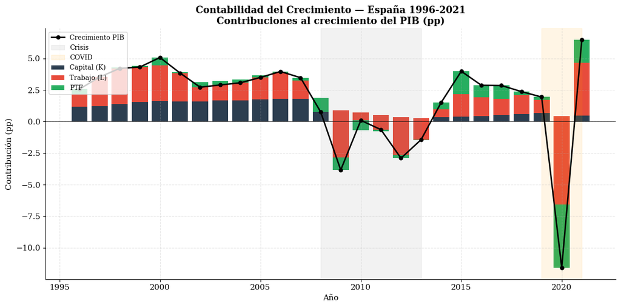

```
✓ Growth accounting exportado
```

```python
import matplotlib.pyplot as plt
import matplotlib.patches as mpatches

fig, ax = plt.subplots(figsize=(12, 6))

years = df_diff['year'].tolist()
contrib_k   = (df_diff['contrib_K'] * 100).tolist()
contrib_l   = (df_diff['contrib_L'] * 100).tolist()
contrib_ptf = (df_diff['contrib_PTF'] * 100).tolist()
gdp_growth  = (df_diff['dln_GDP'] * 100).tolist()

ax.bar(years, contrib_k, label='Capital (K)', color='#2c3e50')
ax.bar(years, contrib_l, bottom=contrib_k, label='Trabajo (L)', color='#e74c3c')
ax.bar(years, contrib_ptf,
       bottom=[k+l for k,l in zip(contrib_k, contrib_l)],
       label='PTF', color='#27ae60')
ax.plot(years, gdp_growth, color='black', linewidth=2,
        marker='o', markersize=5, label='Crecimiento PIB')

ax.axhline(0, color='black', linewidth=0.5)
ax.axvspan(2008, 2013, alpha=0.1, color='gray', label='Crisis')
ax.axvspan(2019, 2021, alpha=0.1, color='orange', label='COVID')

ax.set_title('Contabilidad del Crecimiento — España 1996-2021\nContribuciones al crecimiento del PIB (pp)',
             fontsize=13, fontfamily='serif')
ax.set_xlabel('Año', fontsize=11)
ax.set_ylabel('Contribución (pp)', fontsize=11)
ax.legend(loc='upper left', fontsize=9)
ax.grid(alpha=0.3, linestyle='--')
ax.spines['top'].set_visible(False)
ax.spines['right'].set_visible(False)

plt.tight_layout()
plt.savefig('exports/growth_accounting.png', dpi=200, bbox_inches='tight')
plt.show()
print("✓ Growth accounting exportado")
```

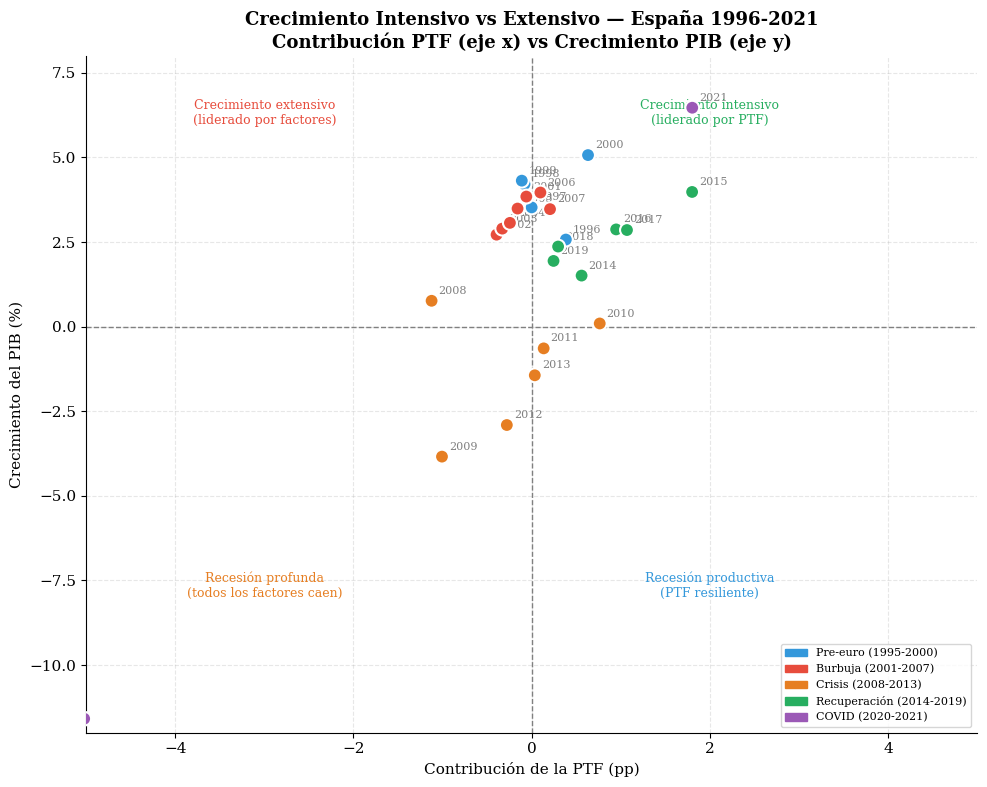

```
✓ Intensivo vs extensivo exportado
```

```python
fig, ax = plt.subplots(figsize=(10, 8))

colores_scatter = []
for year in df_diff['year']:
    if year <= 2000:   colores_scatter.append('#3498db')
    elif year <= 2007: colores_scatter.append('#e74c3c')
    elif year <= 2013: colores_scatter.append('#e67e22')
    elif year <= 2019: colores_scatter.append('#27ae60')
    else:              colores_scatter.append('#9b59b6')

x = (df_diff['contrib_PTF'] * 100).tolist()
y = (df_diff['dln_GDP'] * 100).tolist()
years = df_diff['year'].tolist()

ax.scatter(x, y, c=colores_scatter, s=100, zorder=5, edgecolors='white', linewidth=1.5)

for i, year in enumerate(years):
    ax.annotate(str(year), (x[i], y[i]),
                textcoords='offset points', xytext=(5, 5), fontsize=8, color='gray')

ax.axvline(0, color='gray', linestyle='--', linewidth=1)
ax.axhline(0, color='gray', linestyle='--', linewidth=1)

ax.text(2, 6, "Crecimiento intensivo\n(liderado por PTF)", color='#27ae60', fontsize=9, ha='center')
ax.text(-3, 6, "Crecimiento extensivo\n(liderado por factores)", color='#e74c3c', fontsize=9, ha='center')
ax.text(2, -8, "Recesión productiva\n(PTF resiliente)", color='#3498db', fontsize=9, ha='center')
ax.text(-3, -8, "Recesión profunda\n(todos los factores caen)", color='#e67e22', fontsize=9, ha='center')

from matplotlib.patches import Patch
leyenda = [
    Patch(color='#3498db', label='Pre-euro (1995-2000)'),
    Patch(color='#e74c3c', label='Burbuja (2001-2007)'),
    Patch(color='#e67e22', label='Crisis (2008-2013)'),
    Patch(color='#27ae60', label='Recuperación (2014-2019)'),
    Patch(color='#9b59b6', label='COVID (2020-2021)')
]
ax.legend(handles=leyenda, loc='lower right', fontsize=8)

ax.set_title('Crecimiento Intensivo vs Extensivo — España 1996-2021\nContribución PTF (eje x) vs Crecimiento PIB (eje y)',
             fontsize=13, fontfamily='serif')
ax.set_xlabel('Contribución de la PTF (pp)', fontsize=11)
ax.set_ylabel('Crecimiento del PIB (%)', fontsize=11)
ax.set_xlim(-5, 5)
ax.set_ylim(-12, 8)
ax.grid(alpha=0.3, linestyle='--')
ax.spines['top'].set_visible(False)
ax.spines['right'].set_visible(False)

plt.tight_layout()
plt.savefig('exports/intensivo_extensivo.png', dpi=200, bbox_inches='tight')
plt.show()
print("✓ Intensivo vs extensivo exportado")
```

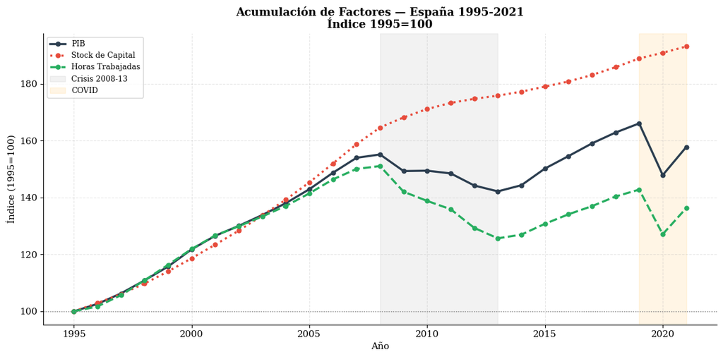

```
✓ Factor accumulation exportado
```

```python
fig, ax = plt.subplots(figsize=(12, 6))

df_idx = df.copy()
for col in ['GDP', 'K', 'L']:
    df_idx[f'{col}_idx'] = (df[col] / df[df['year']==1995][col].values[0]) * 100

ax.plot(df_idx['year'], df_idx['GDP_idx'], color='#2c3e50', linewidth=2.5,
        marker='o', markersize=5, label='PIB')
ax.plot(df_idx['year'], df_idx['K_idx'], color='#e74c3c', linewidth=2.5,
        marker='o', markersize=5, linestyle='dotted', label='Stock de Capital')
ax.plot(df_idx['year'], df_idx['L_idx'], color='#27ae60', linewidth=2.5,
        marker='o', markersize=5, linestyle='dashed', label='Horas Trabajadas')

ax.axhline(100, color='gray', linestyle='dotted', linewidth=1)
ax.axvspan(2008, 2013, alpha=0.1, color='gray', label='Crisis 2008-13')
ax.axvspan(2019, 2021, alpha=0.1, color='orange', label='COVID')

ax.set_title('Acumulación de Factores — España 1995-2021\nÍndice 1995=100',
             fontsize=13, fontfamily='serif')
ax.set_xlabel('Año', fontsize=11)
ax.set_ylabel('Índice (1995=100)', fontsize=11)
ax.legend(fontsize=9)
ax.grid(alpha=0.3, linestyle='--')
ax.spines['top'].set_visible(False)
ax.spines['right'].set_visible(False)

plt.tight_layout()
plt.savefig('exports/factor_accumulation.png', dpi=200, bbox_inches='tight')
plt.show()
print("✓ Factor accumulation exportado")
```